# 2015-02-05-XuetingWu-Assignment1

Xueting Wu

February 04, 2015

**1.Go to this link to retrieve general metadata for Local Government Areas (LGAs) of Nigeria. LGAs are akin to counties in the U.S.**

```r
setwd("/Users/xuetingwu/data-viz/r")
#By forking the upstream repository, the general metadata for LGAs is already on the local drive. So just assign a name "data1" to the .csv
data1 <- read.csv("/Users/xuetingwu/data-viz/r/lgas.csv")
```

Explore the data a little bit to get familiar with it:

(1)How is the data organized?

```r
head(data1)  # first 6 observations of the dataset.
```

```
##   lga_id       unique_lga pop_2006       lga     state          zone
## 1      1     borno_abadam   100180    Abadam     Borno     Northeast
## 2      2        fct_abaji    58444     Abaji       FCT North-Central
## 3      3   akwa_ibom_abak   139090      Abak Akwa Ibom   South-South
## 4      4 ebonyi_abakaliki   151723 Abakaliki    Ebonyi     Southeast
## 5      5   abia_aba_north   107488 Aba North      Abia     Southeast
## 6      6   abia_aba_south   423852 Aba South      Abia     Southeast
##   area_sq_km surveying_effort pop_density_2006 longitude  latitude
## 1 3967.05423           Others         25.25299 13.325674 13.428293
## 2  992.36124              113         58.89388  6.853414  8.877566
## 3  189.98456           Others        732.11211  7.772279  5.019887
## 4  584.05517           Others        259.77512  8.219882  6.258681
## 5   22.77506           Others       4719.54826  7.371644  5.106900
## 6   49.16654           Others       8620.74053  7.350650  5.081346
##   senatorial_district                       TA_names
## 1               North               Mukhtar Abubakar
## 2                                      Ipah Iloye A.
## 3         Ikot Ekpene                    Jesse Akpan
## 4        Ebonyi North             Obasi Arisi Ikenna
## 5          Abia South Anichukwueze Anthony Nkemdirim
## 6          Abia South          Ujah Chukwudu Francis
```

```r
str(data1)  # a more programming-oriented sense including the class of each element
```

```
## 'data.frame':    774 obs. of  13 variables:
##  $ lga_id             : int  1 2 3 4 5 6 7 8 9 10 ...
##  $ unique_lga         : Factor w/ 773 levels "abia_aba_north",..: 142 275 39 211 1 2 563 564 169 292 ...
##  $ pop_2006           : int  100180 58444 139090 151723 107488 423852 201329 250278 144802 195652 ...
##  $ lga                : Factor w/ 768 levels "Aba North","Aba South",..: 3 4 5 6 1 2 7 8 9 10 ...
##  $ state              : Factor w/ 37 levels "Abia","Adamawa",..: 8 15 3 11 1 1 28 28 9 17 ...
##  $ zone               : Factor w/ 6 levels "North-Central",..: 2 1 4 5 5 5 6 6 4 5 ...
##  $ area_sq_km         : num  3967.1 992.4 190 584.1 22.8 ...
##  $ surveying_effort   : Factor w/ 4 levels "113","148","Others",..: 3 1 3 3 3 3 3 3 3 3 ...
##  $ pop_density_2006   : num  25.3 58.9 732.1 259.8 4719.5 ...
##  $ longitude          : num  13.33 6.85 7.77 8.22 7.37 ...
##  $ latitude           : num  13.43 8.88 5.02 6.26 5.11 ...
##  $ senatorial_district: Factor w/ 67 levels "","Abia Central",..: 40 1 33 21 4 4 42 42 12 53 ...
##  $ TA_names           : Factor w/ 121 levels "Abdul Samad Isah Haruna",..: 75 57 62 83 19 114 108 108 94 80 ...
```

(2)How big is the data?

```r
dim(data1) # the dimension of the dataset
```

```
## [1] 774  13
```

(3)How complete is the data?

```r
sum(is.na(data1))  #count the number of NAs in the LGAs dataset
```

```
## [1] 5
```

**2. Next, download the full NMIS dataset, and grab the [large] .csv file called “Health_Mopup_and_Baseline_NMIS_Facility.csv”. This contains every health facility in Nigeria.**

```r
data2 <- read.csv("/Users/xuetingwu/data-viz/r/nmis_dataset/Health_Mopup_and_Baseline_NMIS_Facility.csv") # import the data
# get a general idea about the data
head(data2)
```

```
##                         facility_name
## 1                 HEALTH POST KAGBANG
## 2                       Alhari Clinic
## 3 Primary health centre umukuru okehi
## 4                    PHC EHOM CENTRAL
## 5                         Health post
## 6                 Tula Medical Centre
##                         facility_type_display
## 1                                 Health Post
## 2                 Primary Health Centre (PHC)
## 3 Basic Health Centre / Primary Health Clinic
## 4                 Primary Health Centre (PHC)
## 5                                 Health Post
## 6                                 Health Post
##   maternal_health_delivery_services emergency_transport
```

[output cut: 69 more lines]

```r
str(data2)
```

```
## 'data.frame':    34139 obs. of  30 variables:
##  $ facility_name                    : Factor w/ 28550 levels "\nModel pry healthcare",..: 10496 1224 23082 20322 10286 26394 10563 27789 14315 16562 ...
##  $ facility_type_display            : Factor w/ 18 levels "Basic Health Centre / Primary Health Clinic",..: 9 14 1 14 9 9 9 16 16 9 ...
##  $ maternal_health_delivery_services: logi  TRUE TRUE TRUE TRUE TRUE TRUE ...
##  $ emergency_transport              : logi  TRUE TRUE TRUE FALSE FALSE TRUE ...
##  $ skilled_birth_attendant          : logi  FALSE TRUE TRUE FALSE FALSE TRUE ...
##  $ num_chews_fulltime               : int  1 4 2 2 0 0 0 1 4 1 ...
##  $ phcn_electricity                 : logi  TRUE TRUE TRUE FALSE FALSE FALSE ...
##  $ c_section_yn                     : logi  FALSE FALSE TRUE FALSE FALSE TRUE ...
##  $ child_health_measles_immun_calc  : logi  TRUE TRUE TRUE TRUE TRUE FALSE ...
##  $ num_nurses_fulltime              : int  0 1 4 0 0 2 1 6 NA 0 ...
##  $ num_nursemidwives_fulltime       : int  0 1 11 0 0 0 0 12 4 0 ...
##  $ num_doctors_fulltime             : int  0 1 2 0 0 1 0 5 15 0 ...
##  $ date_of_survey                   : Factor w/ 323 levels "2009-07-23","2010-10-20",..: 240 273 249 242 242 244 240 241 241 262 ...
##  $ facility_id                      : Factor w/ 34122 levels "AAABW","AAADE",..: 28724 10619 10978 16657 17973 17419 13808 10914 12589 15203 ...
```

[output cut: 16 more lines]

```r
dim(data2)
```

```
## [1] 34139    30
```

**3. Produce a new data.frame with the following properties:**

(1)From the NMIS Health Facilities Inventory, select all facilities located in the Southern zones of Nigeria.

```r
table(data1$zone)
```

```
##
## North-Central     Northeast     Northwest   South-South     Southeast
##           121           112           187           122            95
##     Southwest
##           137
```

```r
southz <- subset(data1,zone %in% c("South-South","Southeast","Southwest")) # select the southern zone from LGAs metadata
dim(southz)
```

```
## [1] 354  13
```

```r
122+95+137 # check the subsetting process
```

```
## [1] 354
```

```r
fsouthz <- subset(data2, unique_lga %in% southz$unique_lga) # select facilities located in the Southern zones of Nigeria according to "unique_lga" in dataset "southz"
```

(2)Incorporate LGA metadata into this new dataframe.

```r
m <- merge(southz, fsouthz, by="unique_lga")
dim(fsouthz)-dim(m)  # check the merging process and the result is as expected
```

```
## [1]   0 -12
```

check the operation of building the new data.frame using another approach:

```r
data3 <- merge(data1, data2, by="unique_lga")
dim(data2)-dim(data3)  # check the merging process. Considering the number of rows was reduced by 948, there are 948 observations in data2 whose unique_lga don't match any of the unique_lga in data1 possibily due to typing errors.
```

```
## [1] 948 -12
```

```r
m2 <- subset(data3,zone =="South-South"| zone=="Southeast"| zone=="Southwest")  # select facilities in the southern zone from the new dataset
dim(m)-dim(m2)  # compare the two data.frames which are supposed to be equal
```

```
## [1] 0 0
```

**4. Calculate the total number of full time nurses and doctors for all health facilities, by state. Compute per capita and per area values, as well.**

(1)Sort the resulting dataset by state population, in descending order.

```r
library(plyr)
# to get rid of NAs without having to remove the whole observation
data3$num_nurses_fulltime[is.na(data3$num_nurses_fulltime)]=0
data3$num_nursemidwives_fulltime[is.na(data3$num_nursemidwives_fulltime)]=0
data3$num_doctors_fulltime[is.na(data3$num_doctors_fulltime)]=0
data3$fultotal <- data3$num_nurses_fulltime + data3$num_nursemidwives_fulltime+data3$num_doctors_fulltime  #nursemidwives are also counted as fulltime nurses
which(colnames(data3)=="fultotal")
```

```
## [1] 43
```

```r
Fulltime_Total<-aggregate(data3[43],list(data3$state),sum)
which(colnames(data1)=="pop_2006")
```

```
## [1] 3
```

```r
State_Pop <- aggregate(data1[3], list(data1$state), sum)
which(colnames(data1)=="area_sq_km")
```

```
## [1] 7
```

```r
State_Area_Sq_Km <- aggregate(data1[7], list(data1$state), sum)
Newdata1 <- merge(Fulltime_Total, State_Pop, by= "Group.1" )
Newdata2 <- merge(Newdata1, State_Area_Sq_Km, by= "Group.1" )
names(Newdata2)[1] <- "state"
Newdata3 <- transform(Newdata2, new = fultotal / pop_2006)
Newdata2$per_capita <- Newdata2$fultotal/Newdata2$pop_2006
Newdata2$per_area_unit <- Newdata2$fultotal/Newdata2$area_sq_km
Newdata_Sorted <- arrange(Newdata2, desc(pop_2006))
```

(2)Show the results!

```r
print(Newdata_Sorted)
```

```
##          state fultotal pop_2006 area_sq_km   per_capita per_area_unit
## 1         Kano     1347  9546529  20790.265 0.0001410984   0.064789940
## 2        Lagos     9028  9013534   3479.717 0.0010016049   2.594463957
## 3       Kaduna     2073  5913562  44220.770 0.0003505501   0.046878424
## 4          Oyo     4417  5591589  27900.302 0.0007899365   0.158313700
## 5      Katsina      916  5506778  23823.893 0.0001663405   0.038448795
## 6       Rivers     2908  5185400  10363.981 0.0005608053   0.280587147
## 7       Bauchi     1685  4676438  48168.152 0.0003603170   0.034981620
## 8       Jigawa      497  4348649  23404.072 0.0001142884   0.021235621
## 9        Borno     1777  4251193  72655.785 0.0004180003   0.024457791
## 10       Benue     3199  4219244  30748.258 0.0007581927   0.104038414
## 11     Anambra     3807  4182032   4762.182 0.0009103230   0.799423488
## 12       Delta     3538  4098391  17105.597 0.0008632656   0.206832891
## 13       Niger     1756  3950229  72116.147 0.0004445312   0.024349609
## 14         Imo     4904  3934899   5136.055 0.0012462836   0.954818360
```

[output cut: 23 more lines]

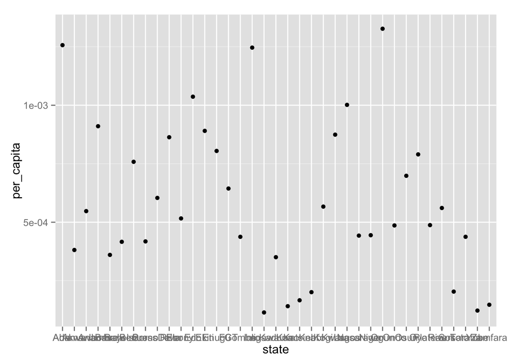

```r
library(ggplot2)
ggplot(Newdata_Sorted, aes(x=state, y=per_capita))+geom_point()
```

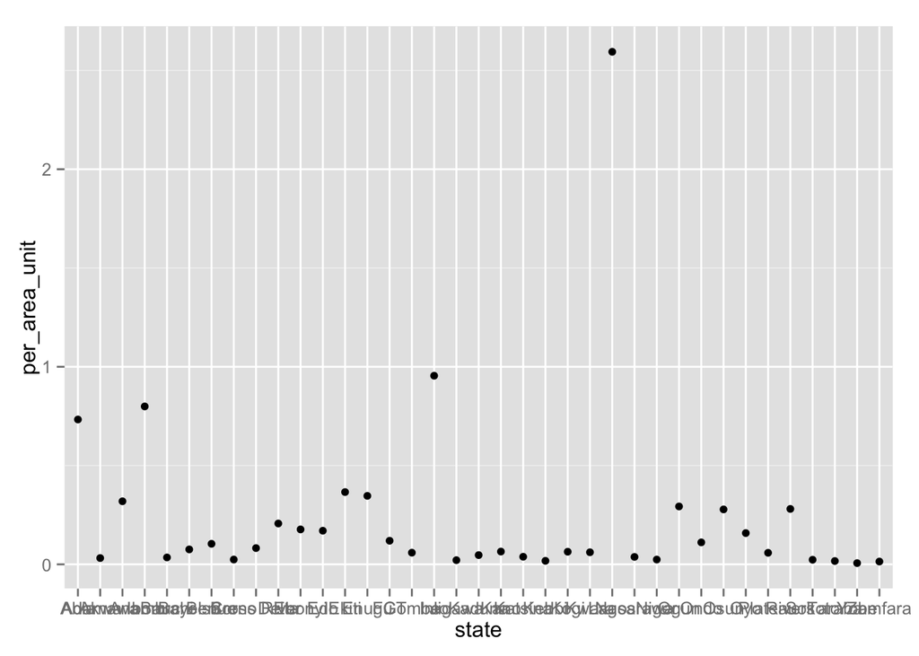

```r
ggplot(Newdata_Sorted, aes(x=state, y=per_area_unit))+geom_point()
```

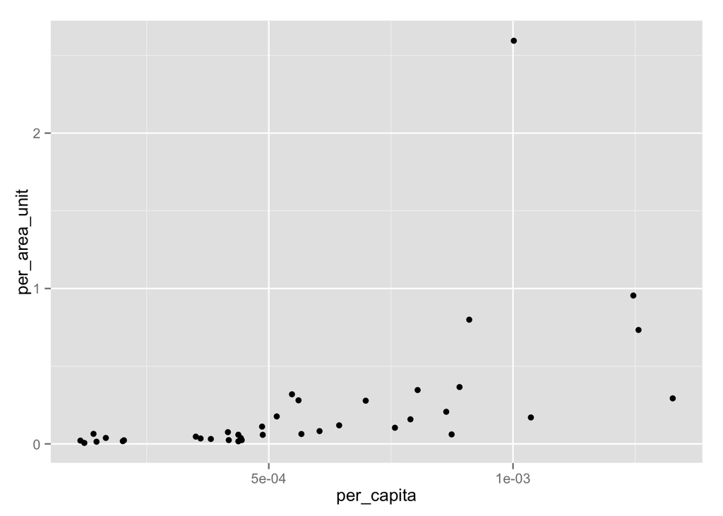

```r
ggplot(Newdata_Sorted, aes(x=per_capita, y=per_area_unit, colours=state))+geom_point()
```